# Predavanje 1 - 2.del - Risanje podatkov s knjižnico ggplot2

Lara Lusa

Hitra povezava na dokument z navodili za pripravo grafikonov s knjižnico [ggplot2 (cheat sheet)](https://github.com/rstudio/cheatsheets/raw/master/data-visualization-2.1.pdf)

## Uvod v ggplot 2

```
library(ggplot2)
library(gridExtra)
```

V Rmarkdown-u: uporabiti `warnings=FALSE` in `message=FALSE`, da bi preprečili pojav neželenih obvestil v dokumentu.

```r
require(ggplot2)
require(gridExtra)
```

Za risanje podatkov s knjižnico `ggplot2` morajo biti podatki vključeni v podatkovni okvir (data frame).

### Kaj sestavi graf

- podatki (v data frame)
- geometrijski elementi: `geom_*` (kjer lahko dolocimo: barve, velikosti, polozaje.). Vsak graf mora imeti vsaj en `geom`. Lahko vsebujejo estetične lastnosti (`aes()`). Primeri `geom_*`
  - `geom_histogram()`: histogram
  - `geom_boxplot()`: okvir z rocaji
  - `geom_points()`: točke, razsevni diagram
  - `geom_line()`: premica
  - `geom_text()`: tekstovne oznake
  - ….
- mapiranje podatkov `aes()`: tisto, kar lahko vidite
  - `mapping=aes(x=Sex, y=Height, ...)`
  - dodatni parametri: color (zunanje barve), fill (notranje barve), position, shape (oblika tock), size, linetype, …
  - Posebnost: vrednosti, ki se lahko spreminjajo (in so odvisne od kaksne spremenljivke), so dolocene znotraj aes(), fiksne vrednosti izven aes()! Primer `aes(x=Height, color=Sex)` je v redu, `aes(x=Height, color="white")` ni! color bo specificiran izven aes!
  - ponavadi je mapping določen znotraj geom, lahko pa tudi v osnovnem ggplot(), če želimo uporabiti povsod isti aes (najpogosteje je to v redu)
- pozicija (position): kako urediti geom, ki bi se nahajale na istem mestu, ponavadi specificirano znotraj geom (ampak izven aes())
  - `geom_point(position = "jitter")`
  - `geom_bar(position = "stack")`
  - `geom_bar(position = "dodge")`
- skale (scales)
  - `scale_x_continuous()`, `scale_y_continuous()`: zvezne osi
  - `scale_*_discrete()`: diskretne osi
  - `scale_*_log10()`: logaritemska transformacija
- `coord_*` koordinatni sistem
  - `coor_cartesian()`: kartezični koordinatni sistem
  - `coor_filp()`: obrne x in y osi v kartezičnem koordinatnem sistemu
- faceting: risanje po podskupinah
  - `facet_grid(.~.)`
  - `facet_wrap(.~.)`
- tema: oblika grafikona
  - `theme_classic()`
  - `theme_bw()`

Dodatne uporabne možnosti

- statistične transformacije `stat()`
- imenovanje `labs(x="oznaka na x osi", y="oznaka na y osi", title="naslov")`
- legende `labs(x="oznaka na x osi", y="oznaka na y osi", title="naslov")`

### Primeri

- Uvozimo prečiščene podatke o anketah. Uporabimo spodnji ukaz

`my.data <- read.delim(file="https://sites.google.com/site/larasfiles/Home/Students1012.txt?attredirects=0&d=1")`

#### Razsevni diagram

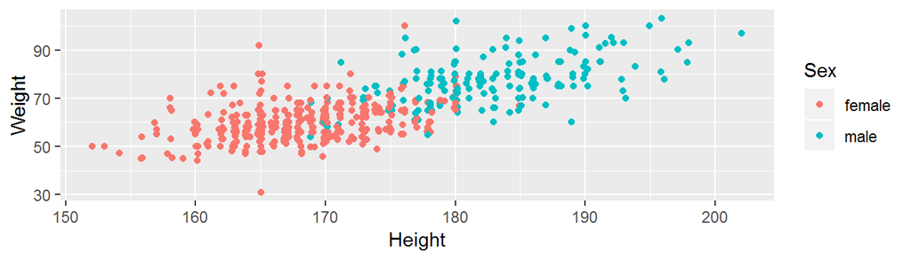

```r
ggplot(my.data, aes(Height, Weight, color=Sex))+geom_point(position="jitter")
```

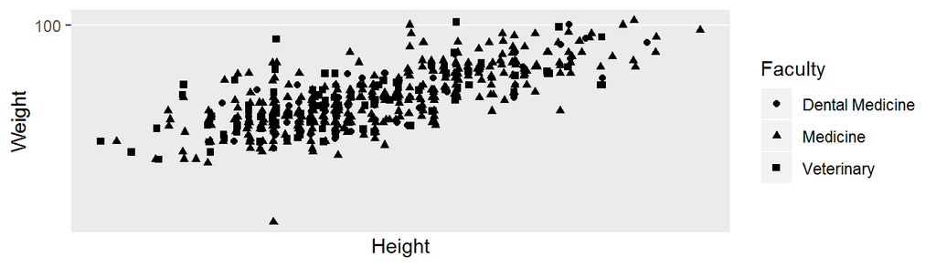

```r
ggplot(my.data, aes(Height, Weight, shape=Faculty))+geom_point(position="jitter")+scale_x_log10()+scale_y_log10()
```

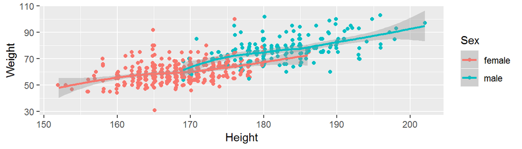

```r
ggplot(my.data, aes(Height, Weight, color=Sex))+geom_point(position="jitter")+geom_smooth()
```

#### Okvir z ročaji

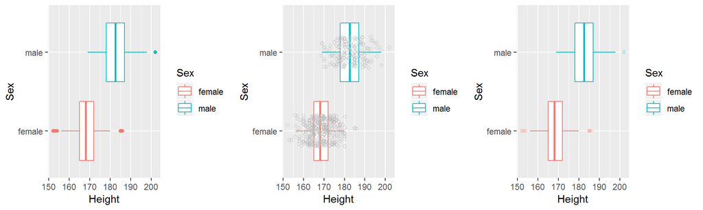

```r
#library(gridExtra)

p1 <- ggplot(my.data, aes(Sex, Height, color=Sex))+geom_boxplot()+coord_flip()

p2 <- ggplot(my.data, aes(Sex, Height, color=Sex))+geom_boxplot(outlier.colour ="transparent") + geom_jitter(shape=1, position=position_jitter(0.2), col="gray")+coord_flip()

p3 <- ggplot(my.data, aes(Sex, Height, color=Sex))+geom_boxplot(outlier.alpha = .2)+coord_flip()

gridExtra::grid.arrange(p1, p2, p3, nrow=1)
```

#### Histogram

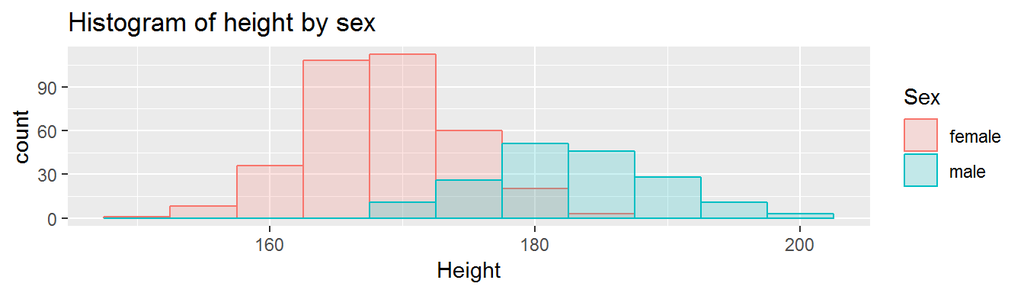

```r
ggplot(my.data, aes(Height, fill=Sex, col=Sex))+geom_histogram(position="identity", binwidth = 5, alpha=0.2)+labs(title="Histogram of height by sex")
```

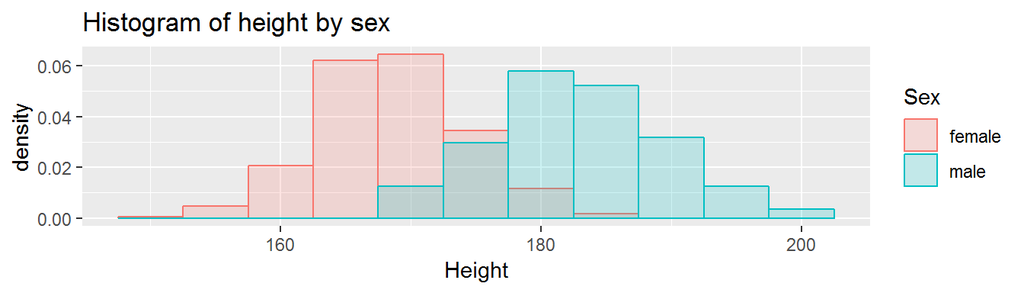

```r
ggplot(my.data, aes(Height, fill=Sex, col=Sex))+geom_histogram(aes(y=..density..), position="identity", binwidth = 5, alpha=0.2)+labs(title="Histogram of height by sex")
```

#### Gostota

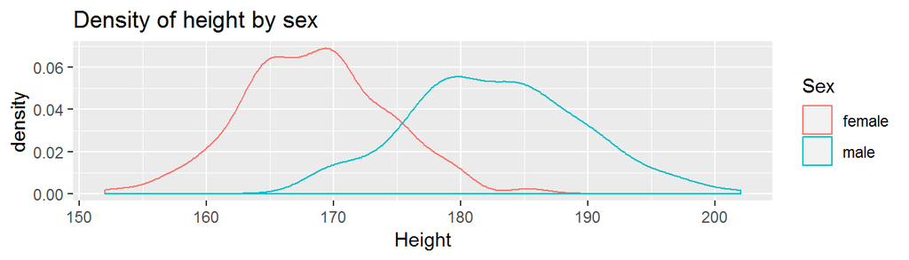

```r
ggplot(my.data)+geom_density(aes(Height, col=Sex))+labs(title="Density of height by sex")
```

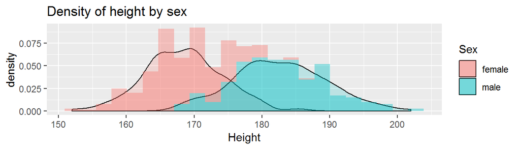

```r
ggplot(my.data, aes(Height, fill=Sex))+geom_density(aes(fill=Sex), alpha=.2)+geom_histogram(aes(y=..density..), binwidth = density(my.data$Height)$bw, alpha=0.4)+labs(title="Density of height by sex")
```

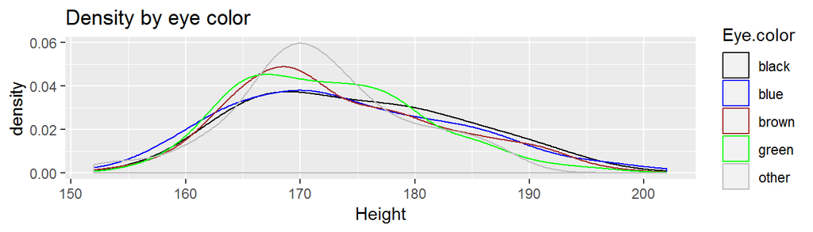

```r
ggplot(my.data, aes(Height, col=Eye.Color))+geom_density()+labs(title="Density by eye color")+scale_colour_manual(name = "Eye.color",values = c("black", "blue",  "brown", "green","gray" ))
```

#### Stolpični diagram

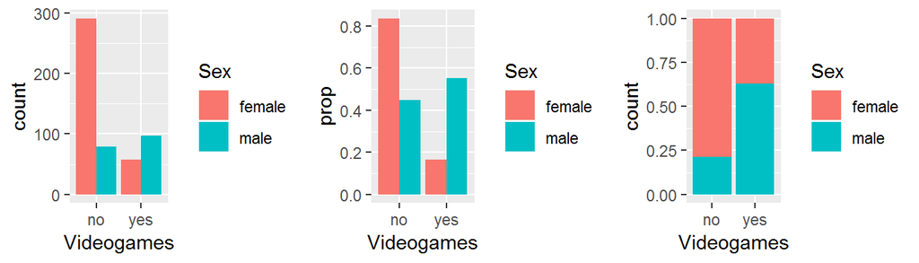

```r
p1 <- ggplot(my.data, aes(Videogames, fill=Sex))+geom_bar(position="dodge")
p2 <- ggplot(my.data)+geom_bar(position="dodge", aes(Videogames, y=..prop.., group=Sex, fill=Sex))
p3 <- ggplot(my.data, aes(Videogames, fill=Sex))+geom_bar(position="fill")

grid.arrange(p1, p2, p3, nrow=1)
```

#### Črte

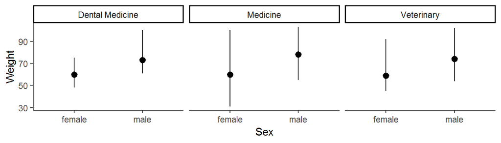

```r
ggplot(my.data)+stat_summary(mapping = aes(x = Sex, y = Weight),  fun.ymin = min, fun.ymax = max, fun.y = median)+ facet_wrap(Faculty~.)+theme_classic()
```

### Naloga

- Narišite histogram višine vseh studentov (Namig: uporabili bomo `geom_histogram()`), naj bo širina razredov 10 cm, barva stolpcev bela, na y-osi napisite “Frekvenca”, na x-osi “Visina”.
  - Korak 1: Povejte R-u, kaj so podatki in katero sprememenlivko zelite narisati

  `p <- ggplot(data=my.data, aes(x=Height))`

Ta ukaz ne bo narisal nobenega grafikona! Program se ne ve, katere vrste grafikona želite narisati.

```
 + Korak 2: Dodajte nivo (layer),  s katerim pretvorite podatke v grafikonu (eksplicitno povejte, da zelite narisati histogram). `geom_*`, ki narise histogram se imenuje `geom_histogram()` Dodamo nivoje z znakom `+`. (Posebnost ggplot-a je, da mora biti  `+` znak v isti vrstici kot prejšnji del ukaza.)
```

`ggplot(data=my.data, aes(x=Height)) + geom_histogram()`

Ker smo shranili prvi grafikon z imenom `p`, lahko napišemo ukaz tudi kot

`p <- p + geom_histogram()`

Za prikaz grafikona vtipkamo `print(p)` ali samo `p` v ukazno okno.

```
+ Korak 3: Naj bodo stolpci histograma bele barve (`fill`), širina razredov 10 (`binwidth`) in naj bo zunanja barva stopcev črna (`color`). Namig: določite nastavitve znotraj funkcije `geom_histogram()`.
```

[figure not shown]

```r
p <- ggplot(my.data, aes(x=Height))
p2 <- p + geom_histogram()
print(p2)
```

Posebnost: zakaj ne najdete opcije `binwidth` v `? geom_histogram()`? `binwidth` je opcija funkcije `stat_bin()`! Tisto, kar v resnici počnemo je vsebovano v naslednjem ukazu.

`ggplot(my.data, aes(x=Height)) + geom_histogram(stat = "bin", binwidth=10)`

Če bi zeleli narisati histogram gostote, bi uporabili ukaz, s katerim bi povedali, da želimo povzeti podatke glede gostote (in ne glede razredov).

`ggplot(my.data, aes(x=Height)) + geom_histogram(stat = "density")`

```
+ Korak 3b: Organizirajte podakte v frekvencno tabelo z razredi sirine 10 cm.
```

`my.table=table(cut(my.data$Height, seq(150, 210, by=10)))`

`my.data.table=cbind.data.frame(Razred=names(my.table), Frekvenca=as.numeric(my.table) )`

in narišite stolpični diagram s podatki (`geom_bar`). Namig: ker so podatki že urejeni v frekvenčno tabelo, boste morali uporabiti `stat="identity"`.

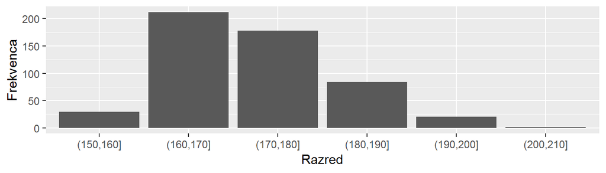

```
+ Korak 4: Dodajte se slovenska imena na x in y osi. Pomagajte si funkcijo `labs()`.
```

```r
ggplot(data=my.data, aes(Height))+geom_histogram(binwidth = 10, color="black", fill="white")+
  labs(x="Visina", y="Frekvenca")
```

```
+ Korak 5: Spremenite lokacijo razredov, tako da bodo razredi se vedno širine 10 cm, ampak naj bodo  začetne točke razredov 150cm, 160cm, itd.
```

```r
ggplot(data=my.data, aes(Height))+geom_histogram(breaks=seq(150, 210, by=10), color="black", fill="white")+
  labs(x="Visina", y="Frekvenca")
```

```
+ Korak 5b: Narišite histogram z obrnjenimi osmi (na x osi naj bodo frekvence, vrednosti višine na y osi).
```

```r
ggplot(data=my.data, aes(Height))+geom_histogram(breaks=seq(150, 210, by=10), color="black", fill="white")+
  labs(x="Visina", y="Frekvenca") + coord_flip()
```

```
+ Korak 6: Narišite histogram višine loceno glede spola študentov (Namig: `facet_grid()`).
```

```r
ggplot(my.data, aes(Height))+geom_histogram(breaks=seq(150, 210, by=10), color="black", fill="white")+
  labs(x="Visina", y="Frekvenca")+facet_grid(Sex~.)
```

```
+ Korak 7: Narišite histogram višine loceno glede spola in fakutete študentov (Namig: `facet_grid()`).
```

```r
ggplot(my.data, aes(Height))+geom_histogram(breaks=seq(150, 210, by=10), color="black", fill="white")+
  labs(x="Visina", y="Frekvenca")+facet_grid(Sex~Faculty)
```